# Leaf modeling

Josh Lee

Saturday, January 24, 2015

#### 1. Load data

##### Load base training/test dataset and ensure proper class assignments

```r
base.tt = read.csv("C:/Users/Joshua/Google Drive/MSBA/Capstone/Morton/Modeling/tt123.csv")
# visually verify import
View(base.tt)
nrow(base.tt)
```

```
## [1] 18885
```

```r
str(base.tt)
```

```
## 'data.frame':    18885 obs. of  15 variables:
##  $ CnMem.1.01.Standing                : Factor w/ 2 levels "churn","no churn": 2 2 2 2 2 2 2 2 2 2 ...
##  $ Memid                              : int  129546 10425 122517 140771 140893 130952 140901 135037 118480 140903 ...
##  $ Visits                             : int  0 5 1 0 1 18 22 1 5 42 ...
##  $ NetAmt                             : num  0 0 0 0 0 15 30 211 0 5 ...
##  $ Age.Group                          : Factor w/ 9 levels "","20s","30s",..: NA 6 NA 5 4 6 7 NA 4 NA ...
##  $ Rental                             : int  0 0 0 0 0 0 0 0 0 0 ...
##  $ Bday_party                         : int  0 0 0 0 0 0 0 0 0 0 ...
##  $ Events                             : int  0 0 0 0 0 2 2 4 0 0 ...
##  $ CnAttrCat.5.01.Description         : Factor w/ 2 levels "","Donor": 2 2 1 1 1 1 1 2 2 1 ...
##  $ CnBio.Constit.Code                 : Factor w/ 4 levels "Employee","Individuals",..: 1 2 2 2 2 2 2 1 2 2 ...
##  $ CnBio.Age                          : int  NA 68 NA 58 49 68 70 NA 49 NA ...
##  $ CnMem.1.01.Consecutive.Years       : int  6 6 13 9 9 11 9 10 14 9 ...
##  $ CnMem.1.01.Cur.Category.description: Factor w/ 16 levels "2 YR Family Plus",..: 11 15 11 9 12 10 12 14 12 9 ...
##  $ Distance                           : num  5.19 10.14 5.46 4.89 1.64 ...
##  $ donations                          : int  NA NA NA NA NA NA NA NA NA NA ...
```

```r
base.tt$Memid = as.factor(base.tt$Memid)
base.tt$Visits = as.numeric(base.tt$Visits)
base.tt$Rental = as.numeric(base.tt$Rental)
base.tt$Bday_party = as.numeric(base.tt$Bday_party)
base.tt$CnBio.Age = as.numeric(base.tt$CnBio.Age)
base.tt$CnMem.1.01.Consecutive.Years = as.numeric(base.tt$CnMem.1.01.Consecutive.Years)

# make adjustments - convert na values in donation field to 0; the assumption made here is that if no donation trans were found in cp data, then they made no donations.  na implies it's a missing value, which under this assumption it is not.
base.tt$donations[is.na(base.tt$donations)] = 0

# set convert target/response value to factor.  but may need to conver to numeric for some models won't accept factor values
base.tt$CnMem.1.01.Standing = ifelse(base.tt$CnMem.1.01.Standing == "churn", "1", "0")
base.tt$CnMem.1.01.Standing = as.factor(base.tt$CnMem.1.01.Standing)
levels(base.tt$CnMem.1.01.Standing)
```

```
## [1] "0" "1"
```

#### 2. Dealing with missing values

##### Option 1: remove instances with missing values

```r
# see how many instnaces have missing values
nrow(base.tt[!complete.cases(base.tt),]) / nrow(base.tt) # 49% have missing values
```

```
## [1] 0.4868
```

```r
# function to summarize NAs in each column of dataframe
checkna <- function(dataframe) {
  m <- sapply(dataframe, function(x) {
        data.frame(
            All_Records=length(x),
      NAs=sum(is.na(x)),
            NAPercent=sum(is.na(x))/length(x)
        )
    })
    d <- data.frame(t(m))
    d <- sapply(d, unlist)
    d <- as.data.frame(d)
    d$variable <- row.names(d)
    row.names(d) <- NULL
    d <- cbind(d[ncol(d)],d[-ncol(d)])
    return(d[order(d$NAPercent), ])
}

checkna(base.tt) # shows that age and age group accounts for nearly all na values.
```

```
##                               variable All_Records  NAs NAPercent
## 1                  CnMem.1.01.Standing       18885    0 0.0000000
## 2                                Memid       18885    0 0.0000000
## 3                               Visits       18885    0 0.0000000
## 4                               NetAmt       18885    0 0.0000000
## 6                               Rental       18885    0 0.0000000
## 7                           Bday_party       18885    0 0.0000000
## 8                               Events       18885    0 0.0000000
## 9           CnAttrCat.5.01.Description       18885    0 0.0000000
## 10                  CnBio.Constit.Code       18885    0 0.0000000
## 12        CnMem.1.01.Consecutive.Years       18885    0 0.0000000
## 13 CnMem.1.01.Cur.Category.description       18885    0 0.0000000
## 15                           donations       18885    0 0.0000000
## 14                            Distance       18885    3 0.0001589
## 5                            Age.Group       18885 9193 0.4867885
## 11                           CnBio.Age       18885 9193 0.4867885
```

```r
# remove age and age group
base.tt.sansage = subset(base.tt, select = -c(Age.Group, CnBio.Age))
checkna(base.tt.sansage)
```

```
##                               variable All_Records NAs NAPercent
## 1                  CnMem.1.01.Standing       18885   0 0.0000000
## 2                                Memid       18885   0 0.0000000
## 3                               Visits       18885   0 0.0000000
## 4                               NetAmt       18885   0 0.0000000
## 5                               Rental       18885   0 0.0000000
## 6                           Bday_party       18885   0 0.0000000
## 7                               Events       18885   0 0.0000000
## 8           CnAttrCat.5.01.Description       18885   0 0.0000000
## 9                   CnBio.Constit.Code       18885   0 0.0000000
## 10        CnMem.1.01.Consecutive.Years       18885   0 0.0000000
## 11 CnMem.1.01.Cur.Category.description       18885   0 0.0000000
## 13                           donations       18885   0 0.0000000
## 12                            Distance       18885   3 0.0001589
```

```r
# Version 1 - excluding age variables, remove the few na instnaces in the Distance variable
base.tt.excludeAge = base.tt.sansage[complete.cases(base.tt.sansage),]
checkna(base.tt.excludeAge)
```

```
##                               variable All_Records NAs NAPercent
## 1                  CnMem.1.01.Standing       18882   0         0
## 2                                Memid       18882   0         0
## 3                               Visits       18882   0         0
## 4                               NetAmt       18882   0         0
## 5                               Rental       18882   0         0
## 6                           Bday_party       18882   0         0
## 7                               Events       18882   0         0
## 8           CnAttrCat.5.01.Description       18882   0         0
## 9                   CnBio.Constit.Code       18882   0         0
## 10        CnMem.1.01.Consecutive.Years       18882   0         0
## 11 CnMem.1.01.Cur.Category.description       18882   0         0
## 12                            Distance       18882   0         0
## 13                           donations       18882   0         0
```

```r
# version 2 - including age variables, remove all na instnaces (approx 50%)
base.tt.includeAge = base.tt[complete.cases(base.tt),]
checkna(base.tt.includeAge)
```

```
##                               variable All_Records NAs NAPercent
## 1                  CnMem.1.01.Standing        9692   0         0
## 2                                Memid        9692   0         0
## 3                               Visits        9692   0         0
## 4                               NetAmt        9692   0         0
## 5                            Age.Group        9692   0         0
## 6                               Rental        9692   0         0
## 7                           Bday_party        9692   0         0
## 8                               Events        9692   0         0
## 9           CnAttrCat.5.01.Description        9692   0         0
## 10                  CnBio.Constit.Code        9692   0         0
## 11                           CnBio.Age        9692   0         0
## 12        CnMem.1.01.Consecutive.Years        9692   0         0
## 13 CnMem.1.01.Cur.Category.description        9692   0         0
## 14                            Distance        9692   0         0
## 15                           donations        9692   0         0
```

> Determined that the vast majority of NA values were attributable to the Age variables and a few instances to the Distance variable. Hence, created two versions of the file with NA values ommitted: 1) excluding age variables and 2) including age variables. The version including age variables resulted in approx half of the instances being removed. The version excluding age variables retained most of the instances, but obviously lost the age variables as predictors.

##### Option 2: impute missing values

```r
# Fill-in the unknowns with the most common value (a statistic of centrality)
library(DMwR)
base.tt.CI = centralImputation(base.tt)
checkna(base.tt.CI)
```

```
##                               variable All_Records NAs NAPercent
## 1                  CnMem.1.01.Standing       18885   0         0
## 2                                Memid       18885   0         0
## 3                               Visits       18885   0         0
## 4                               NetAmt       18885   0         0
## 5                            Age.Group       18885   0         0
## 6                               Rental       18885   0         0
## 7                           Bday_party       18885   0         0
## 8                               Events       18885   0         0
## 9           CnAttrCat.5.01.Description       18885   0         0
## 10                  CnBio.Constit.Code       18885   0         0
## 11                           CnBio.Age       18885   0         0
## 12        CnMem.1.01.Consecutive.Years       18885   0         0
## 13 CnMem.1.01.Cur.Category.description       18885   0         0
## 14                            Distance       18885   0         0
## 15                           donations       18885   0         0
```

```r
# Fill-in with the most common value on the cases that are more "similar" to the one with unknowns
base.tt.KI = knnImputation(base.tt, k=10)
checkna(base.tt.KI)
```

```
##                               variable All_Records NAs NAPercent
## 1                  CnMem.1.01.Standing       18885   0         0
## 2                                Memid       18885   0         0
## 3                               Visits       18885   0         0
## 4                               NetAmt       18885   0         0
## 5                            Age.Group       18885   0         0
## 6                               Rental       18885   0         0
## 7                           Bday_party       18885   0         0
## 8                               Events       18885   0         0
## 9           CnAttrCat.5.01.Description       18885   0         0
## 10                  CnBio.Constit.Code       18885   0         0
## 11                           CnBio.Age       18885   0         0
## 12        CnMem.1.01.Consecutive.Years       18885   0         0
## 13 CnMem.1.01.Cur.Category.description       18885   0         0
## 14                            Distance       18885   0         0
## 15                           donations       18885   0         0
```

##### Option 3: do nothing and allow model to account for missing values (only works for certain tree models)

```r
# n/a - use base.tt
```

##### remove Memid

```r
base.tt.excludeAge = subset(base.tt.excludeAge, select=-c(Memid))
base.tt.includeAge = subset(base.tt.includeAge, select=-c(Memid))
base.tt.CI = subset(base.tt.CI, select=-c(Memid))
base.tt.KI = subset(base.tt.KI, select=-c(Memid))

str(base.tt.excludeAge)
```

```
## 'data.frame':    18882 obs. of  12 variables:
##  $ CnMem.1.01.Standing                : Factor w/ 2 levels "0","1": 1 1 1 1 1 1 1 1 1 1 ...
##  $ Visits                             : num  0 5 1 0 1 18 22 1 5 42 ...
##  $ NetAmt                             : num  0 0 0 0 0 15 30 211 0 5 ...
##  $ Rental                             : num  0 0 0 0 0 0 0 0 0 0 ...
##  $ Bday_party                         : num  0 0 0 0 0 0 0 0 0 0 ...
##  $ Events                             : int  0 0 0 0 0 2 2 4 0 0 ...
##  $ CnAttrCat.5.01.Description         : Factor w/ 2 levels "","Donor": 2 2 1 1 1 1 1 2 2 1 ...
##  $ CnBio.Constit.Code                 : Factor w/ 4 levels "Employee","Individuals",..: 1 2 2 2 2 2 2 1 2 2 ...
##  $ CnMem.1.01.Consecutive.Years       : num  6 6 13 9 9 11 9 10 14 9 ...
##  $ CnMem.1.01.Cur.Category.description: Factor w/ 16 levels "2 YR Family Plus",..: 11 15 11 9 12 10 12 14 12 9 ...
##  $ Distance                           : num  5.19 10.14 5.46 4.89 1.64 ...
##  $ donations                          : num  0 0 0 0 0 0 0 0 0 0 ...
```

> Accounting for missing values has resulted in the following data sets:
- Option 1: remove missing values
- base.tt.excludeAge: excluding age variables and removing all na instances
- base.tt.includeAge: including age variables and removing all na instances
- Option 2: impute values
- base.tt.CI: Fill-in the unknowns with the most common value
- base.tt.KI: Fill-in with the most common value on the cases that are more “similar” to the one with unknowns
- Option 3: do nothing and allow models to account for missing values
- base.tt

#### 3. skewness and outliers (numerical variables)

##### analyze for skewness

```r
# identify the continuous varibles to measure skewness: Visits, NetAmt, Rental, Bday_party, Events, CnMem.1.01.Consecutive.Years

numerics.age = c("Visits", "NetAmt", "Rental", "Bday_party", "Events", "CnBio.Age", "CnMem.1.01.Consecutive.Years", "Distance")
numerics.noage = c("Visits", "NetAmt", "Rental", "Bday_party", "Events", "CnMem.1.01.Consecutive.Years", "Distance")

base.tt.excludeAge.N = base.tt.excludeAge[,numerics.noage]
base.tt.includeAge.N = base.tt.includeAge[,numerics.age]
base.tt.CI.N = base.tt.CI[,numerics.age]
base.tt.KI.N = base.tt.KI[,numerics.age]
base.tt.N = base.tt[,numerics.age]

library(e1071)
skewness.INAge = apply(base.tt.includeAge.N, 2, skewness)
skewness.INAge
```

```
##                       Visits                       NetAmt
##                      9.90911                     22.09345
##                       Rental                   Bday_party
##                     58.43827                     58.43827
##                       Events                    CnBio.Age
##                      5.28156                      0.02008
## CnMem.1.01.Consecutive.Years                     Distance
##                      1.86429                     36.25228
```

```r
skewness.EXAge = apply(base.tt.excludeAge.N, 2, skewness)
skewness.EXAge
```

```
##                       Visits                       NetAmt
##                       10.155                       20.240
##                       Rental                   Bday_party
##                       56.466                       56.466
##                       Events CnMem.1.01.Consecutive.Years
##                        5.736                        2.292
##                     Distance
##                       28.661
```

```r
skewness.CI = apply(base.tt.CI.N, 2, skewness)
skewness.CI
```

```
##                       Visits                       NetAmt
##                     10.15541                     20.24131
##                       Rental                   Bday_party
##                     56.47092                     56.47092
##                       Events                    CnBio.Age
##                      5.73633                     -0.05916
## CnMem.1.01.Consecutive.Years                     Distance
##                      2.29164                     28.66343
```

```r
skewness.KI = apply(base.tt.KI.N, 2, skewness)
skewness.KI
```

```
##                       Visits                       NetAmt
##                      10.1554                      20.2413
##                       Rental                   Bday_party
##                      56.4709                      56.4709
##                       Events                    CnBio.Age
##                       5.7363                       0.3731
## CnMem.1.01.Consecutive.Years                     Distance
##                       2.2916                      28.6634
```

```r
skewness.base = apply(base.tt.N, 2, skewness)
skewness.base
```

```
##                       Visits                       NetAmt
##                       10.155                       20.241
##                       Rental                   Bday_party
##                       56.471                       56.471
##                       Events                    CnBio.Age
##                        5.736                           NA
## CnMem.1.01.Consecutive.Years                     Distance
##                        2.292                           NA
```

#### 4. Apply transformations (boxcox, center, scale, pca)

```r
# first apply log transformations to numeric variables - only applied to distance as all other numeric variables contain a significant amount of zeros

base.tt.excludeAge$Distance.log = log(base.tt.excludeAge$Distance)
base.tt.includeAge$Distance.log = log(base.tt.includeAge$Distance)
base.tt.CI$Distance.log = log(base.tt.CI$Distance)
base.tt.KI$Distance.log = log(base.tt.KI$Distance)
base.tt$Distance.log = log(base.tt$Distance)

numerics.age2 = c("Visits", "NetAmt", "Rental", "Bday_party", "Events", "CnBio.Age", "CnMem.1.01.Consecutive.Years", "Distance", "Distance.log")
numerics.noage2 = c("Visits", "NetAmt", "Rental", "Bday_party", "Events", "CnMem.1.01.Consecutive.Years", "Distance", "Distance.log")

# reassess for skewnesss
base.tt.excludeAge.N2 = base.tt.excludeAge[,numerics.noage2]
base.tt.includeAge.N2 = base.tt.includeAge[,numerics.age2]
base.tt.CI.N2 = base.tt.CI[,numerics.age2]
base.tt.KI.N2 = base.tt.KI[,numerics.age2]
base.tt.N2 = base.tt[,numerics.age2]

library(e1071)
skewness.INAge = apply(base.tt.includeAge.N2, 2, skewness)
skewness.INAge
```

```
##                       Visits                       NetAmt
##                      9.90911                     22.09345
##                       Rental                   Bday_party
##                     58.43827                     58.43827
##                       Events                    CnBio.Age
##                      5.28156                      0.02008
## CnMem.1.01.Consecutive.Years                     Distance
##                      1.86429                     36.25228
##                 Distance.log
##                      0.79288
```

```r
skewness.EXAge = apply(base.tt.excludeAge.N2, 2, skewness)
skewness.EXAge
```

```
##                       Visits                       NetAmt
##                      10.1547                      20.2398
##                       Rental                   Bday_party
##                      56.4664                      56.4664
##                       Events CnMem.1.01.Consecutive.Years
##                       5.7359                       2.2916
##                     Distance                 Distance.log
##                      28.6612                       0.9385
```

```r
skewness.CI = apply(base.tt.CI.N2, 2, skewness)
skewness.CI
```

```
##                       Visits                       NetAmt
##                     10.15541                     20.24131
##                       Rental                   Bday_party
##                     56.47092                     56.47092
##                       Events                    CnBio.Age
##                      5.73633                     -0.05916
## CnMem.1.01.Consecutive.Years                     Distance
##                      2.29164                     28.66343
##                 Distance.log
##                      0.93862
```

```r
skewness.KI = apply(base.tt.KI.N2, 2, skewness)
skewness.KI
```

```
##                       Visits                       NetAmt
##                      10.1554                      20.2413
##                       Rental                   Bday_party
##                      56.4709                      56.4709
##                       Events                    CnBio.Age
##                       5.7363                       0.3731
## CnMem.1.01.Consecutive.Years                     Distance
##                       2.2916                      28.6634
##                 Distance.log
##                       0.9384
```

```r
skewness.base = apply(base.tt.N2, 2, skewness)
skewness.base
```

```
##                       Visits                       NetAmt
##                       10.155                       20.241
##                       Rental                   Bday_party
##                       56.471                       56.471
##                       Events                    CnBio.Age
##                        5.736                           NA
## CnMem.1.01.Consecutive.Years                     Distance
##                        2.292                           NA
##                 Distance.log
##                           NA
```

```r
# ignores categorical variables and only applies the preProcess function to numeric varaibles
# essentially replace preProcess with ppWrapper
# saves results as dataframe, which is awesome
ppWrapper = function( x, excludeClasses=c("factor"), ... ) {
    whichToExclude <- sapply( x, function(y) any(sapply(excludeClasses, function(excludeClass) is(y,excludeClass) )) )
    processedMat <- predict( preProcess( x[!whichToExclude], ...), newdata=x[!whichToExclude] )
    x[!whichToExclude] <- processedMat
    x
}

library(caret)
base.tt.excludeAge.Proc = ppWrapper(base.tt.excludeAge, method = c("BoxCox", "center", "scale","pca"))
base.tt.includeAge.Proc = ppWrapper(base.tt.includeAge, method = c("BoxCox", "center", "scale","pca"))
base.tt.CI.Proc = ppWrapper(base.tt.CI, method = c("BoxCox", "center", "scale","pca"))
base.tt.KI.Proc = ppWrapper(base.tt.KI, method = c("BoxCox", "center", "scale","pca"))
base.tt.Proc = ppWrapper(base.tt, method = c("BoxCox", "center", "scale","pca"))

# recheck skewnewss - post-tranformations
library(e1071)
skewness.EXAge.Proc = apply(base.tt.excludeAge.Proc[,numerics.noage2], 2, skewness)
skewness.EXAge.Proc
```

```
##                       Visits                       NetAmt
##                      22.9796                      -9.1156
##                       Rental                   Bday_party
##                      -0.2105                      -6.4938
##                       Events CnMem.1.01.Consecutive.Years
##                      -6.5844                      -3.7505
##                     Distance                 Distance.log
##                      22.9796                      -0.2105
```

```r
skewness.InAge.Proc = apply(base.tt.includeAge.Proc[,numerics.age2], 2, skewness)
skewness.InAge.Proc
```

```
##                       Visits                       NetAmt
##                     -6.87523                    -29.59926
##                       Rental                   Bday_party
##                     -0.14133                     -0.07193
##                       Events                    CnBio.Age
##                     15.33024                      6.23090
## CnMem.1.01.Consecutive.Years                     Distance
##                      0.25060                     -6.87523
##                 Distance.log
##                     -0.14133
```

```r
skewness.CI.Proc = apply(base.tt.CI.Proc[,numerics.age2], 2, skewness)
skewness.CI.Proc
```

```
##                       Visits                       NetAmt
##                     19.36314                    -12.02689
##                       Rental                   Bday_party
##                     -0.25194                      0.06096
##                       Events                    CnBio.Age
##                     20.17584                      5.99522
## CnMem.1.01.Consecutive.Years                     Distance
##                      0.47366                     19.36314
##                 Distance.log
##                     -0.25194
```

```r
skewness.KI.Proc = apply(base.tt.KI.Proc[,numerics.age2], 2, skewness)
skewness.KI.Proc
```

```
##                       Visits                       NetAmt
##                      16.8963                     -14.3283
##                       Rental                   Bday_party
##                      -0.1868                       0.3977
##                       Events                    CnBio.Age
##                      20.2694                       6.9663
## CnMem.1.01.Consecutive.Years                     Distance
##                       0.5980                      16.8963
##                 Distance.log
##                      -0.1868
```

```r
skewness.Proc = apply(base.tt.Proc[,numerics.age2], 2, skewness)
skewness.Proc
```

```
##                       Visits                       NetAmt
##                           NA                           NA
##                       Rental                   Bday_party
##                           NA                           NA
##                       Events                    CnBio.Age
##                           NA                           NA
## CnMem.1.01.Consecutive.Years                     Distance
##                           NA                           NA
##                 Distance.log
##                           NA
```

```r
# remove distance since distance.log created
base.tt.excludeAge.Proc2 = subset(base.tt.excludeAge.Proc, select=-c(Distance))
base.tt.includeAge.Proc2 = subset(base.tt.includeAge.Proc, select=-c(Distance))
base.tt.CI.Proc2 = subset(base.tt.CI.Proc, select=-c(Distance))
base.tt.KI.Proc2 = subset(base.tt.KI.Proc, select=-c(Distance))
base.tt.Proc2 = subset(base.tt.Proc, select=-c(Distance))
```

#### 5. Convert all categorical/nominal variables to numeric Dummy variables

```r
# this is necessary to perform many of the data transformations such as normalize and boxcox.
# for certain classification models, this dummmy conversion may not be the best, so keep in mind...

library(caret)
base.tt.excludeAge.Proc2$CnMem.1.01.Standing = as.numeric(base.tt.excludeAge.Proc2$CnMem.1.01.Standing) #convert target to numeric to prevent dummification
a = dummyVars("~ .", data=base.tt.excludeAge.Proc2, levelsOny=TRUE)
base.tt.excludeAge.Proc.dummy = data.frame(predict(a, newdata = base.tt.excludeAge.Proc2))
base.tt.excludeAge.Proc.dummy$CnMem.1.01.Standing = as.factor(base.tt.excludeAge.Proc.dummy$CnMem.1.01.Standing)# convert back to factor
base.tt.excludeAge.Proc.dummy$CnMem.1.01.Standing = as.factor(ifelse(base.tt.excludeAge.Proc.dummy$CnMem.1.01.Standing == "1", "0", "1"))

base.tt.includeAge.Proc2$CnMem.1.01.Standing = as.numeric(base.tt.includeAge.Proc2$CnMem.1.01.Standing)
b = dummyVars("~ .", data=base.tt.includeAge.Proc2, levelsOny=TRUE)
base.tt.includeAge.Proc.dummy = data.frame(predict(b, newdata = base.tt.includeAge.Proc2))
base.tt.includeAge.Proc.dummy$CnMem.1.01.Standing = as.factor(base.tt.includeAge.Proc.dummy$CnMem.1.01.Standing)
base.tt.includeAge.Proc.dummy$CnMem.1.01.Standing = as.factor(ifelse(base.tt.includeAge.Proc.dummy$CnMem.1.01.Standing == "1", "0", "1"))

base.tt.CI.Proc2$CnMem.1.01.Standing = as.numeric(base.tt.CI.Proc2$CnMem.1.01.Standing)
c = dummyVars("~ .", data=base.tt.CI.Proc2, levelsOny=TRUE)
base.tt.CI.Proc.dummy = data.frame(predict(c, newdata = base.tt.CI.Proc2))
base.tt.CI.Proc.dummy$CnMem.1.01.Standing = as.factor(base.tt.CI.Proc.dummy$CnMem.1.01.Standing)
base.tt.CI.Proc.dummy$CnMem.1.01.Standing = as.factor(ifelse(base.tt.CI.Proc.dummy$CnMem.1.01.Standing == "1", "0", "1"))

base.tt.KI.Proc2$CnMem.1.01.Standing = as.numeric(base.tt.KI.Proc2$CnMem.1.01.Standing)
d = dummyVars("~ .", data=base.tt.KI.Proc2, levelsOny=TRUE)
base.tt.KI.Proc.dummy = data.frame(predict(d, newdata = base.tt.KI.Proc2))
base.tt.KI.Proc.dummy$CnMem.1.01.Standing = as.factor(base.tt.KI.Proc.dummy$CnMem.1.01.Standing)
base.tt.KI.Proc.dummy$CnMem.1.01.Standing = as.factor(ifelse(base.tt.KI.Proc.dummy$CnMem.1.01.Standing == "1", "0", "1"))


# just rerun this to restore the non-dummy sets
base.tt.excludeAge.Proc2 = subset(base.tt.excludeAge.Proc, select=-c(Distance))
base.tt.includeAge.Proc2 = subset(base.tt.includeAge.Proc, select=-c(Distance))
base.tt.CI.Proc2 = subset(base.tt.CI.Proc, select=-c(Distance))
base.tt.KI.Proc2 = subset(base.tt.KI.Proc, select=-c(Distance))
base.tt.Proc2 = subset(base.tt.Proc, select=-c(Distance))
```

> Created the following files with transformed numeric variables and dummified nominal variables: - base.tt.excludeAge.Proc.dummy  
> - base.tt.includeAge.Proc.dummy - base.tt.CI.Proc.dummy - base.tt.KI.Proc.dummy

#### 6a. Data Splitting - holdouts and auc on Dummy sets

```r
#### Dummy sets - excludeAge

library(caret)
# simple 60/40 random sampling splitting based on target
set.seed(777)
trainIndex = createDataPartition(base.tt.excludeAge.Proc.dummy$CnMem.1.01.Standing, p=.6, list=FALSE,times=1)

BTEPD.TRN = base.tt.excludeAge.Proc.dummy[trainIndex,]
BTEPD.TST = base.tt.excludeAge.Proc.dummy[-trainIndex,]

#j48
library(pROC)
library(RWeka)
J48.TRN.BTEPD = J48(CnMem.1.01.Standing ~ ., BTEPD.TRN) # train on test set
J48.TST.BTEPD = predict(J48.TRN.BTEPD, BTEPD.TST, type="prob") # apply model on holdout set to get pred class and class

BTEPD.TST$J48prob = J48.TST.BTEPD[,"1"]
J48.BTEPD.ROC = roc(response = BTEPD.TST$CnMem.1.01.Standing, predictor = BTEPD.TST$J48prob)
auc(J48.BTEPD.ROC)
```

```
## Area under the curve: 0.998
```

```r
ci.roc(J48.BTEPD.ROC)
```

```
## 95% CI: 0.997-0.999 (DeLong)
```

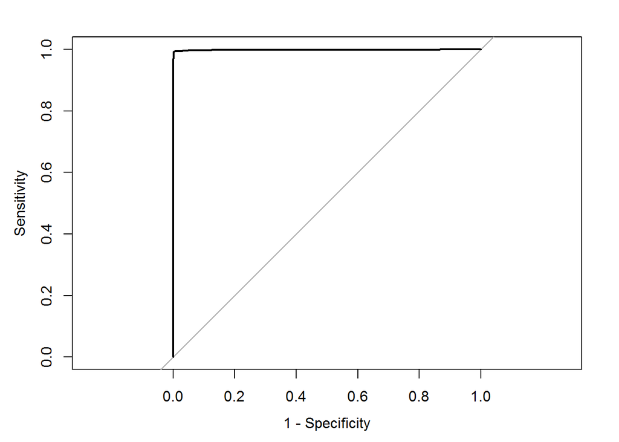

```
##
## Call:
## roc.default(response = BTEPD.TST$CnMem.1.01.Standing, predictor = BTEPD.TST$J48prob)
##
## Data: BTEPD.TST$J48prob in 4446 controls (BTEPD.TST$CnMem.1.01.Standing 0) < 3106 cases (BTEPD.TST$CnMem.1.01.Standing 1).
## Area under the curve: 0.998
```

```r
plot(J48.BTEPD.ROC, legacy.axes = TRUE)
```

```r
#j48 - weka verification
library(partykit)
#plot(J48.TRN.BTEPD)
eval_J48.BTEPD = evaluate_Weka_classifier(J48.TRN.BTEPD, BTEPD.TST, class=TRUE)
eval_J48.BTEPD
```

```
##
## === Summary ===
##
## Correctly Classified Instances        7514               99.4968 %
## Incorrectly Classified Instances        38                0.5032 %
## Kappa statistic                          0.9896
## Mean absolute error                      0.0068
## Root mean squared error                  0.0672
## Relative absolute error                  1.4044 %
## Root relative squared error             13.6569 %
## Coverage of cases (0.95 level)          99.616  %
## Mean rel. region size (0.95 level)      50.3112 %
## Total Number of Instances             7552
##
## === Detailed Accuracy By Class ===
##
##                  TP Rate  FP Rate  Precision  Recall   F-Measure  MCC      ROC Area  PRC Area  Class
##                  0.996    0.007    0.995      0.996    0.996      0.990    0.998     0.997     0
##                  0.993    0.004    0.995      0.993    0.994      0.990    0.998     0.997     1
## Weighted Avg.    0.995    0.006    0.995      0.995    0.995      0.990    0.998     0.997
##
## === Confusion Matrix ===
##
##     a    b   <-- classified as
##  4430   16 |    a = 0
##    22 3084 |    b = 1
```

```r
#randomForest
library(randomForest)
rf.TRN.BTEPD = randomForest(CnMem.1.01.Standing ~ ., BTEPD.TRN)
rf.TST.BTEPD = predict(rf.TRN.BTEPD, BTEPD.TST, type="prob")

BTEPD.TST$rfprob = rf.TST.BTEPD[,"1"]
rf.BTEPD.ROC = roc(response = BTEPD.TST$CnMem.1.01.Standing, predictor = BTEPD.TST$rfprob)
auc(rf.BTEPD.ROC)
```

```
## Area under the curve: 1
```

```r
ci.roc(rf.BTEPD.ROC)
```

```
## 95% CI: 1-1 (DeLong)
```

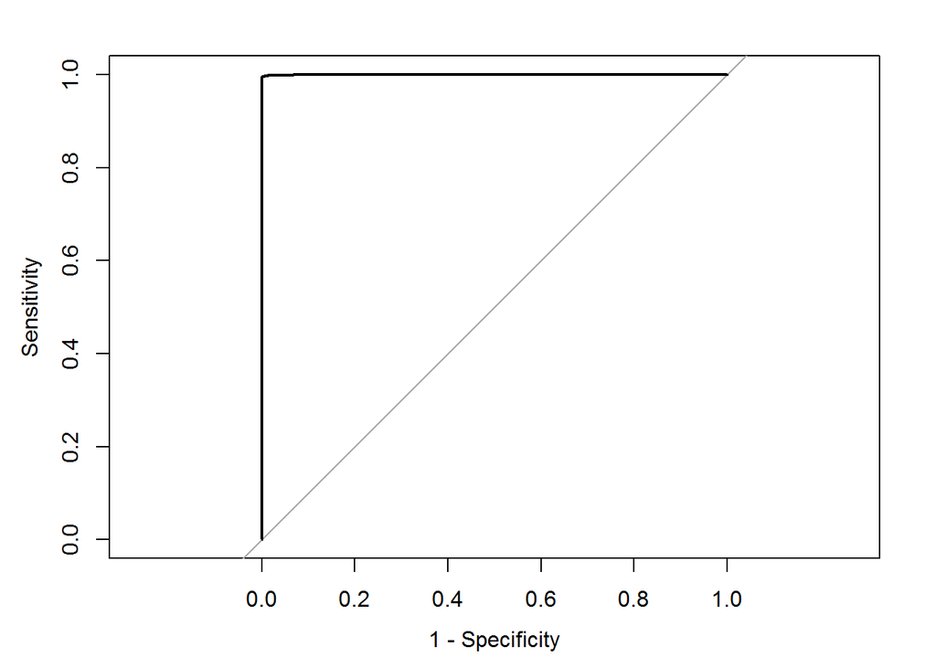

```
##
## Call:
## roc.default(response = BTEPD.TST$CnMem.1.01.Standing, predictor = BTEPD.TST$rfprob)
##
## Data: BTEPD.TST$rfprob in 4446 controls (BTEPD.TST$CnMem.1.01.Standing 0) < 3106 cases (BTEPD.TST$CnMem.1.01.Standing 1).
## Area under the curve: 1
```

```r
plot(rf.BTEPD.ROC, legacy.axes = TRUE)
```

```r
#svm
library(kernlab)
svm.TRN.BTEPD = ksvm(CnMem.1.01.Standing ~ ., BTEPD.TRN, prob.model=TRUE)
```

```
## Using automatic sigma estimation (sigest) for RBF or laplace kernel
```

```r
svm.TST.BTEPD = predict(svm.TRN.BTEPD, BTEPD.TST, type="prob")

BTEPD.TST$svmprob = svm.TST.BTEPD[,"1"]
svm.BTEPD.ROC = roc(response = BTEPD.TST$CnMem.1.01.Standing, predictor = BTEPD.TST$svmprob)
auc(svm.BTEPD.ROC)
```

```
## Area under the curve: 1
```

```r
ci.roc(svm.BTEPD.ROC)
```

```
## 95% CI: 1-1 (DeLong)
```

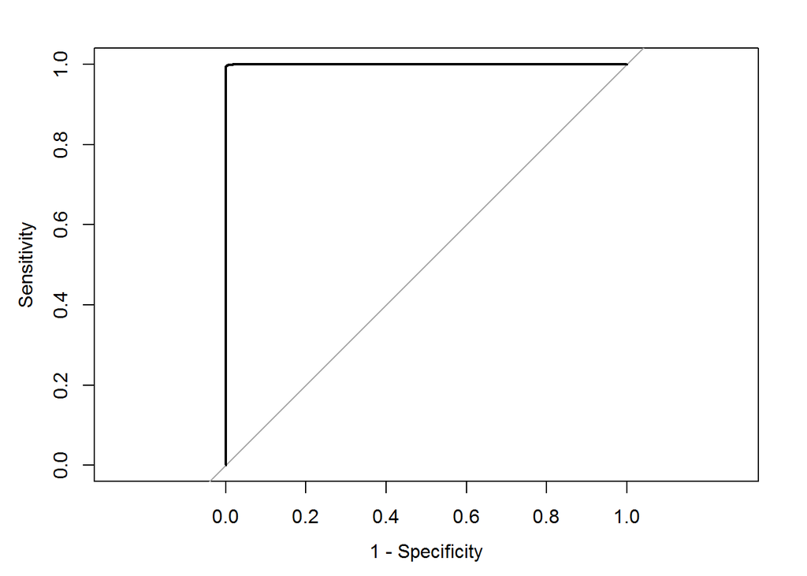

```
##
## Call:
## roc.default(response = BTEPD.TST$CnMem.1.01.Standing, predictor = BTEPD.TST$svmprob)
##
## Data: BTEPD.TST$svmprob in 4446 controls (BTEPD.TST$CnMem.1.01.Standing 0) < 3106 cases (BTEPD.TST$CnMem.1.01.Standing 1).
## Area under the curve: 1
```

```r
plot(svm.BTEPD.ROC, legacy.axes = TRUE)
```

```r
##### Dummy sets - includeAge

set.seed(777)
trainIndex.i = createDataPartition(base.tt.includeAge.Proc.dummy$CnMem.1.01.Standing, p=.6, list=FALSE,times=1)

BTiPD.TRN = base.tt.includeAge.Proc.dummy[trainIndex.i,]
BTiPD.TST = base.tt.includeAge.Proc.dummy[-trainIndex.i,]

#j48
J48.TRN.BTiPD = J48(CnMem.1.01.Standing ~ ., BTiPD.TRN) # train on test set
J48.TST.BTiPD = predict(J48.TRN.BTiPD, BTiPD.TST, type="prob") # apply model on holdout set to get pred class and class

BTiPD.TST$J48prob = J48.TST.BTiPD[,"1"]
J48.BTiPD.ROC = roc(response = BTiPD.TST$CnMem.1.01.Standing, predictor = BTiPD.TST$J48prob)
auc(J48.BTiPD.ROC)
```

```
## Area under the curve: 0.959
```

```r
ci.roc(J48.BTiPD.ROC)
```

```
## 95% CI: 0.951-0.966 (DeLong)
```

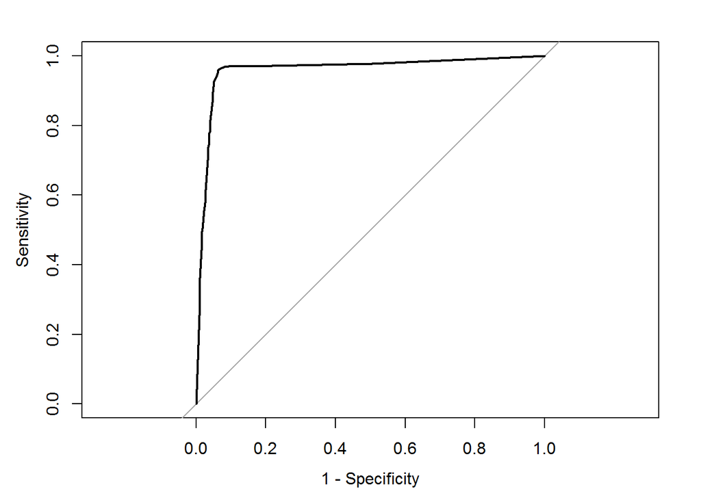

```
##
## Call:
## roc.default(response = BTiPD.TST$CnMem.1.01.Standing, predictor = BTiPD.TST$J48prob)
##
## Data: BTiPD.TST$J48prob in 2412 controls (BTiPD.TST$CnMem.1.01.Standing 0) < 1464 cases (BTiPD.TST$CnMem.1.01.Standing 1).
## Area under the curve: 0.959
```

```r
plot(J48.BTiPD.ROC, legacy.axes = TRUE)
```

```r
#j48 - weka verification
library(partykit)
#plot(J48.TRN.BTiPD)
eval_J48.BTiPD = evaluate_Weka_classifier(J48.TRN.BTiPD, BTiPD.TST, class=TRUE)
eval_J48.BTiPD
```

```
##
## === Summary ===
##
## Correctly Classified Instances        3662               94.4788 %
## Incorrectly Classified Instances       214                5.5212 %
## Kappa statistic                          0.884
## Mean absolute error                      0.069
## Root mean squared error                  0.2248
## Relative absolute error                 14.67   %
## Root relative squared error             46.3585 %
## Coverage of cases (0.95 level)          96.6718 %
## Mean rel. region size (0.95 level)      56.1404 %
## Total Number of Instances             3876
##
## === Detailed Accuracy By Class ===
##
##                  TP Rate  FP Rate  Precision  Recall   F-Measure  MCC      ROC Area  PRC Area  Class
##                  0.936    0.041    0.974      0.936    0.955      0.885    0.959     0.966     0
##                  0.959    0.064    0.901      0.959    0.929      0.885    0.959     0.919     1
## Weighted Avg.    0.945    0.050    0.947      0.945    0.945      0.885    0.959     0.948
##
## === Confusion Matrix ===
##
##     a    b   <-- classified as
##  2258  154 |    a = 0
##    60 1404 |    b = 1
```

```r
##### Dummy sets - CI imputation

set.seed(777)
trainIndex.ci = createDataPartition(base.tt.CI.Proc.dummy$CnMem.1.01.Standing, p=.6, list=FALSE,times=1)

BTciPD.TRN = base.tt.CI.Proc.dummy[trainIndex.ci,]
BTciPD.TST = base.tt.CI.Proc.dummy[-trainIndex.ci,]

#j48
J48.TRN.BTciPD = J48(CnMem.1.01.Standing ~ ., BTciPD.TRN) # train on test set
J48.TST.BTciPD = predict(J48.TRN.BTciPD, BTciPD.TST, type="prob") # apply model on holdout set to get pred class and class

BTciPD.TST$J48prob = J48.TST.BTciPD[,"1"]
J48.BTciPD.ROC = roc(response = BTciPD.TST$CnMem.1.01.Standing, predictor = BTciPD.TST$J48prob)
auc(J48.BTciPD.ROC)
```

```
## Area under the curve: 0.982
```

```r
ci.roc(J48.BTciPD.ROC)
```

```
## 95% CI: 0.979-0.985 (DeLong)
```

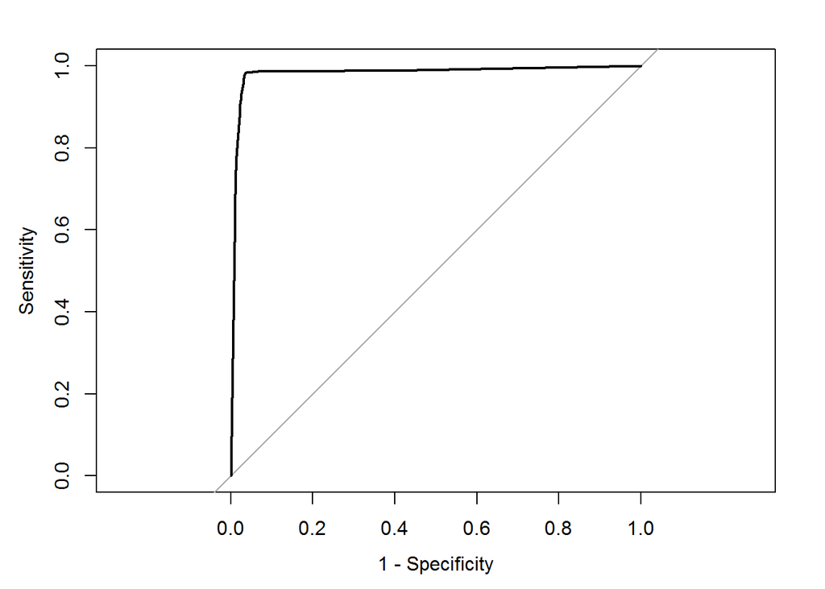

```
##
## Call:
## roc.default(response = BTciPD.TST$CnMem.1.01.Standing, predictor = BTciPD.TST$J48prob)
##
## Data: BTciPD.TST$J48prob in 4446 controls (BTciPD.TST$CnMem.1.01.Standing 0) < 3107 cases (BTciPD.TST$CnMem.1.01.Standing 1).
## Area under the curve: 0.982
```

```r
plot(J48.BTciPD.ROC, legacy.axes = TRUE)
```

```r
#j48 - weka verification
library(partykit)
#plot(J48.TRN.BTciPD)
eval_J48.BTciPD = evaluate_Weka_classifier(J48.TRN.BTciPD, BTciPD.TST, class=TRUE)
eval_J48.BTciPD
```

```
##
## === Summary ===
##
## Correctly Classified Instances        7331               97.0608 %
## Incorrectly Classified Instances       222                2.9392 %
## Kappa statistic                          0.9395
## Mean absolute error                      0.0372
## Root mean squared error                  0.1652
## Relative absolute error                  7.6743 %
## Root relative squared error             33.5789 %
## Coverage of cases (0.95 level)          98.0273 %
## Mean rel. region size (0.95 level)      52.9061 %
## Total Number of Instances             7553
##
## === Detailed Accuracy By Class ===
##
##                  TP Rate  FP Rate  Precision  Recall   F-Measure  MCC      ROC Area  PRC Area  Class
##                  0.966    0.023    0.984      0.966    0.975      0.940    0.982     0.982     0
##                  0.977    0.034    0.953      0.977    0.965      0.940    0.982     0.967     1
## Weighted Avg.    0.971    0.027    0.971      0.971    0.971      0.940    0.982     0.976
##
## === Confusion Matrix ===
##
##     a    b   <-- classified as
##  4295  151 |    a = 0
##    71 3036 |    b = 1
```

```r
##### Dummy sets - KI imputation

set.seed(777)
trainIndex.ki = createDataPartition(base.tt.KI.Proc.dummy$CnMem.1.01.Standing, p=.6, list=FALSE,times=1)

BTkiPD.TRN = base.tt.CI.Proc.dummy[trainIndex.ci,]
BTkiPD.TST = base.tt.CI.Proc.dummy[-trainIndex.ci,]

#j48
J48.TRN.BTkiPD = J48(CnMem.1.01.Standing ~ ., BTkiPD.TRN) # train on test set
J48.TST.BTkiPD = predict(J48.TRN.BTkiPD, BTkiPD.TST, type="prob") # apply model on holdout set to get pred class and class

BTkiPD.TST$J48prob = J48.TST.BTkiPD[,"1"]
J48.BTkiPD.ROC = roc(response = BTkiPD.TST$CnMem.1.01.Standing, predictor = BTkiPD.TST$J48prob)
auc(J48.BTkiPD.ROC)
```

```
## Area under the curve: 0.982
```

```r
ci.roc(J48.BTkiPD.ROC)
```

```
## 95% CI: 0.979-0.985 (DeLong)
```

```r
plot(J48.BTkiPD.ROC, legacy.axes = TRUE)
```

[output not shown]

```
##
## Call:
## roc.default(response = BTkiPD.TST$CnMem.1.01.Standing, predictor = BTkiPD.TST$J48prob)
##
## Data: BTkiPD.TST$J48prob in 4446 controls (BTkiPD.TST$CnMem.1.01.Standing 0) < 3107 cases (BTkiPD.TST$CnMem.1.01.Standing 1).
## Area under the curve: 0.982
```

```r
#j48 - weka verification
library(partykit)
#plot(J48.TRN.BTkiPD)
eval_J48.BTkiPD = evaluate_Weka_classifier(J48.TRN.BTkiPD, BTkiPD.TST, class=TRUE)
eval_J48.BTkiPD
```

```
##
## === Summary ===
##
## Correctly Classified Instances        7331               97.0608 %
## Incorrectly Classified Instances       222                2.9392 %
## Kappa statistic                          0.9395
## Mean absolute error                      0.0372
## Root mean squared error                  0.1652
## Relative absolute error                  7.6743 %
## Root relative squared error             33.5789 %
## Coverage of cases (0.95 level)          98.0273 %
## Mean rel. region size (0.95 level)      52.9061 %
## Total Number of Instances             7553
##
## === Detailed Accuracy By Class ===
##
##                  TP Rate  FP Rate  Precision  Recall   F-Measure  MCC      ROC Area  PRC Area  Class
##                  0.966    0.023    0.984      0.966    0.975      0.940    0.982     0.982     0
##                  0.977    0.034    0.953      0.977    0.965      0.940    0.982     0.967     1
## Weighted Avg.    0.971    0.027    0.971      0.971    0.971      0.940    0.982     0.976
##
## === Confusion Matrix ===
##
##     a    b   <-- classified as
##  4295  151 |    a = 0
##    71 3036 |    b = 1
```

#### 6b. Data Splitting - holdouts and auc on Nondummy sets

```r
#### Nondummy sets - excludeAge

library(caret)
# simple 60/40 random sampling splitting based on target
set.seed(777)
trainIndex.n = createDataPartition(base.tt.excludeAge.Proc2$CnMem.1.01.Standing, p=.6, list=FALSE,times=1)

BTEP.TRN = base.tt.excludeAge.Proc2[trainIndex.n,]
BTEP.TST = base.tt.excludeAge.Proc2[-trainIndex.n,]

#j48
library(pROC)
library(RWeka)
J48.TRN.BTEP = J48(CnMem.1.01.Standing ~ ., BTEP.TRN) # train on test set
J48.TST.BTEP = predict(J48.TRN.BTEP, BTEP.TST, type="prob") # apply model on holdout set to get pred class and class

BTEP.TST$J48prob = J48.TST.BTEP[,"1"]
J48.BTEP.ROC = roc(response = BTEP.TST$CnMem.1.01.Standing, predictor = BTEP.TST$J48prob)
auc(J48.BTEP.ROC)
```

```
## Area under the curve: 0.998
```

```r
ci.roc(J48.BTEP.ROC)
```

```
## 95% CI: 0.997-0.999 (DeLong)
```

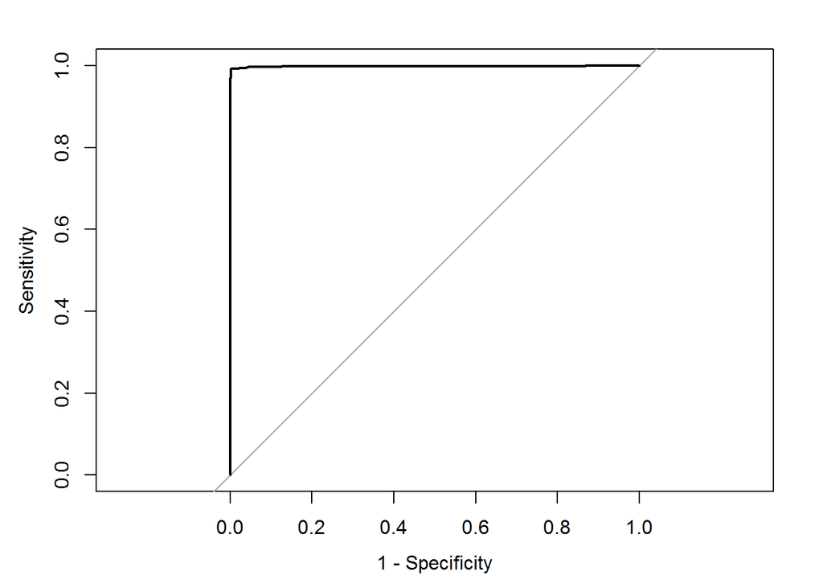

```
##
## Call:
## roc.default(response = BTEP.TST$CnMem.1.01.Standing, predictor = BTEP.TST$J48prob)
##
## Data: BTEP.TST$J48prob in 4446 controls (BTEP.TST$CnMem.1.01.Standing 0) < 3106 cases (BTEP.TST$CnMem.1.01.Standing 1).
## Area under the curve: 0.998
```

```r
plot(J48.BTEP.ROC, legacy.axes = TRUE)
```

```r
#j48 - weka verification
library(partykit)
#plot(J48.TRN.BTEP)
eval_J48.BTEP = evaluate_Weka_classifier(J48.TRN.BTEP, BTEP.TST, class=TRUE)
eval_J48.BTEP
```

```
##
## === Summary ===
##
## Correctly Classified Instances        7523               99.616  %
## Incorrectly Classified Instances        29                0.384  %
## Kappa statistic                          0.9921
## Mean absolute error                      0.0065
## Root mean squared error                  0.0614
## Relative absolute error                  1.3478 %
## Root relative squared error             12.4717 %
## Coverage of cases (0.95 level)          99.7484 %
## Mean rel. region size (0.95 level)      51.4301 %
## Total Number of Instances             7552
##
## === Detailed Accuracy By Class ===
##
##                  TP Rate  FP Rate  Precision  Recall   F-Measure  MCC      ROC Area  PRC Area  Class
##                  0.999    0.007    0.995      0.999    0.997      0.992    0.998     0.998     0
##                  0.993    0.001    0.998      0.993    0.995      0.992    0.998     0.997     1
## Weighted Avg.    0.996    0.005    0.996      0.996    0.996      0.992    0.998     0.998
##
## === Confusion Matrix ===
##
##     a    b   <-- classified as
##  4440    6 |    a = 0
##    23 3083 |    b = 1
```

```r
##### Nondummy sets - includeAge

set.seed(777)
trainIndex.ni = createDataPartition(base.tt.includeAge.Proc2$CnMem.1.01.Standing, p=.6, list=FALSE,times=1)

BTiP.TRN = base.tt.includeAge.Proc2[trainIndex.ni,]
BTiP.TST = base.tt.includeAge.Proc2[-trainIndex.ni,]

#j48
J48.TRN.BTiP = J48(CnMem.1.01.Standing ~ ., BTiP.TRN) # train on test set
J48.TST.BTiP = predict(J48.TRN.BTiP, BTiP.TST, type="prob") # apply model on holdout set to get pred class and class

BTiP.TST$J48prob = J48.TST.BTiP[,"1"]
J48.BTiP.ROC = roc(response = BTiP.TST$CnMem.1.01.Standing, predictor = BTiP.TST$J48prob)
auc(J48.BTiP.ROC)
```

```
## Area under the curve: 0.953
```

```r
ci.roc(J48.BTiP.ROC)
```

```
## 95% CI: 0.945-0.961 (DeLong)
```

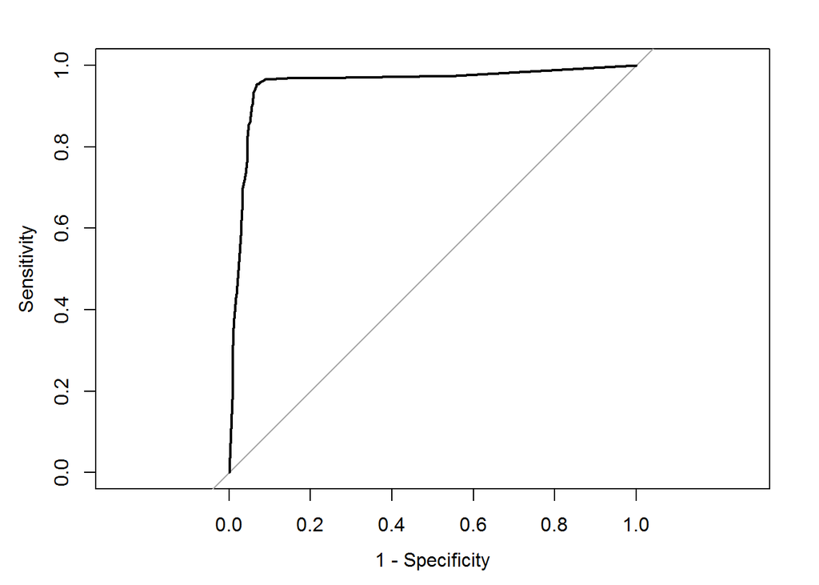

```
##
## Call:
## roc.default(response = BTiP.TST$CnMem.1.01.Standing, predictor = BTiP.TST$J48prob)
##
## Data: BTiP.TST$J48prob in 2412 controls (BTiP.TST$CnMem.1.01.Standing 0) < 1464 cases (BTiP.TST$CnMem.1.01.Standing 1).
## Area under the curve: 0.953
```

```r
plot(J48.BTiP.ROC, legacy.axes = TRUE)
```

```r
#j48 - weka verification
library(partykit)
#plot(J48.TRN.BTiP)
eval_J48.BTiP = evaluate_Weka_classifier(J48.TRN.BTiP, BTiP.TST, class=TRUE)
eval_J48.BTiP
```

```
##
## === Summary ===
##
## Correctly Classified Instances        3641               93.937  %
## Incorrectly Classified Instances       235                6.063  %
## Kappa statistic                          0.8725
## Mean absolute error                      0.0773
## Root mean squared error                  0.2329
## Relative absolute error                 16.447  %
## Root relative squared error             48.0397 %
## Coverage of cases (0.95 level)          96.8008 %
## Mean rel. region size (0.95 level)      58.63   %
## Total Number of Instances             3876
##
## === Detailed Accuracy By Class ===
##
##                  TP Rate  FP Rate  Precision  Recall   F-Measure  MCC      ROC Area  PRC Area  Class
##                  0.933    0.050    0.969      0.933    0.950      0.874    0.953     0.960     0
##                  0.950    0.067    0.896      0.950    0.922      0.874    0.953     0.910     1
## Weighted Avg.    0.939    0.056    0.941      0.939    0.940      0.874    0.953     0.941
##
## === Confusion Matrix ===
##
##     a    b   <-- classified as
##  2250  162 |    a = 0
##    73 1391 |    b = 1
```

```r
##### Dummy sets - CI imputation

set.seed(777)
trainIndex.nci = createDataPartition(base.tt.CI.Proc2$CnMem.1.01.Standing, p=.6, list=FALSE,times=1)

BTciP.TRN = base.tt.CI.Proc2[trainIndex.nci,]
BTciP.TST = base.tt.CI.Proc2[-trainIndex.nci,]

#j48
J48.TRN.BTciP = J48(CnMem.1.01.Standing ~ ., BTciP.TRN) # train on test set
J48.TST.BTciP = predict(J48.TRN.BTciP, BTciP.TST, type="prob") # apply model on holdout set to get pred class and class

BTciP.TST$J48prob = J48.TST.BTciP[,"1"]
J48.BTciP.ROC = roc(response = BTciP.TST$CnMem.1.01.Standing, predictor = BTciP.TST$J48prob)
auc(J48.BTciP.ROC)
```

```
## Area under the curve: 0.984
```

```r
ci.roc(J48.BTciP.ROC)
```

```
## 95% CI: 0.98-0.987 (DeLong)
```

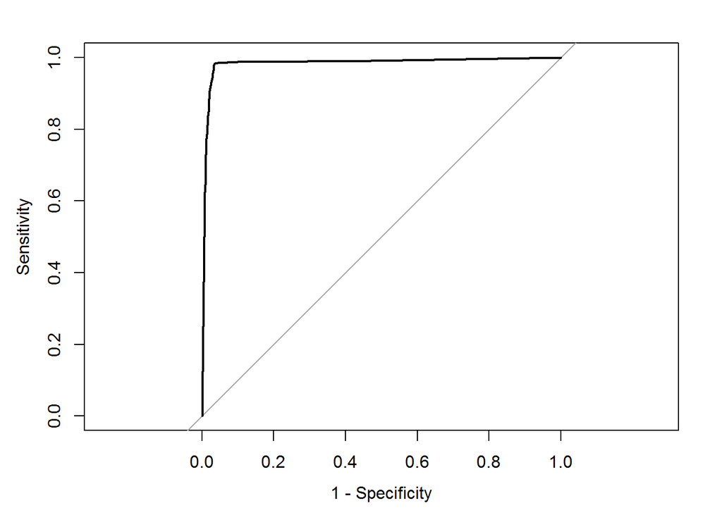

```
##
## Call:
## roc.default(response = BTciP.TST$CnMem.1.01.Standing, predictor = BTciP.TST$J48prob)
##
## Data: BTciP.TST$J48prob in 4446 controls (BTciP.TST$CnMem.1.01.Standing 0) < 3107 cases (BTciP.TST$CnMem.1.01.Standing 1).
## Area under the curve: 0.984
```

```r
plot(J48.BTciP.ROC, legacy.axes = TRUE)
```

```r
#j48 - weka verification
library(partykit)
#plot(J48.TRN.BTciP)
eval_J48.BTciP = evaluate_Weka_classifier(J48.TRN.BTciP, BTciP.TST, class=TRUE)
eval_J48.BTciP
```

```
##
## === Summary ===
##
## Correctly Classified Instances        7339               97.1667 %
## Incorrectly Classified Instances       214                2.8333 %
## Kappa statistic                          0.9418
## Mean absolute error                      0.0378
## Root mean squared error                  0.1622
## Relative absolute error                  7.8034 %
## Root relative squared error             32.9578 %
## Coverage of cases (0.95 level)          98.3715 %
## Mean rel. region size (0.95 level)      54.1374 %
## Total Number of Instances             7553
##
## === Detailed Accuracy By Class ===
##
##                  TP Rate  FP Rate  Precision  Recall   F-Measure  MCC      ROC Area  PRC Area  Class
##                  0.966    0.020    0.986      0.966    0.976      0.942    0.984     0.984     0
##                  0.980    0.034    0.952      0.980    0.966      0.942    0.984     0.971     1
## Weighted Avg.    0.972    0.026    0.972      0.972    0.972      0.942    0.984     0.979
##
## === Confusion Matrix ===
##
##     a    b   <-- classified as
##  4293  153 |    a = 0
##    61 3046 |    b = 1
```

```r
##### Dummy sets - KI imputation

set.seed(777)
trainIndex.nki = createDataPartition(base.tt.KI.Proc2$CnMem.1.01.Standing, p=.6, list=FALSE,times=1)

BTkiP.TRN = base.tt.CI.Proc2[trainIndex.ci,]
BTkiP.TST = base.tt.CI.Proc2[-trainIndex.ci,]

#j48
J48.TRN.BTkiP = J48(CnMem.1.01.Standing ~ ., BTkiP.TRN) # train on test set
J48.TST.BTkiP = predict(J48.TRN.BTkiP, BTkiP.TST, type="prob") # apply model on holdout set to get pred class and class

BTkiP.TST$J48prob = J48.TST.BTkiP[,"1"]
J48.BTkiP.ROC = roc(response = BTkiP.TST$CnMem.1.01.Standing, predictor = BTkiP.TST$J48prob)
auc(J48.BTkiP.ROC)
```

```
## Area under the curve: 0.984
```

```r
ci.roc(J48.BTkiP.ROC)
```

```
## 95% CI: 0.98-0.987 (DeLong)
```

```r
plot(J48.BTkiP.ROC, legacy.axes = TRUE)
```

[output not shown]

```
##
## Call:
## roc.default(response = BTkiP.TST$CnMem.1.01.Standing, predictor = BTkiP.TST$J48prob)
##
## Data: BTkiP.TST$J48prob in 4446 controls (BTkiP.TST$CnMem.1.01.Standing 0) < 3107 cases (BTkiP.TST$CnMem.1.01.Standing 1).
## Area under the curve: 0.984
```

```r
#j48 - weka verification
library(partykit)
#plot(J48.TRN.BTkiP)
eval_J48.BTkiP = evaluate_Weka_classifier(J48.TRN.BTkiP, BTkiP.TST, class=TRUE)
eval_J48.BTkiP
```

```
##
## === Summary ===
##
## Correctly Classified Instances        7339               97.1667 %
## Incorrectly Classified Instances       214                2.8333 %
## Kappa statistic                          0.9418
## Mean absolute error                      0.0378
## Root mean squared error                  0.1622
## Relative absolute error                  7.8034 %
## Root relative squared error             32.9578 %
## Coverage of cases (0.95 level)          98.3715 %
## Mean rel. region size (0.95 level)      54.1374 %
## Total Number of Instances             7553
##
## === Detailed Accuracy By Class ===
##
##                  TP Rate  FP Rate  Precision  Recall   F-Measure  MCC      ROC Area  PRC Area  Class
##                  0.966    0.020    0.986      0.966    0.976      0.942    0.984     0.984     0
##                  0.980    0.034    0.952      0.980    0.966      0.942    0.984     0.971     1
## Weighted Avg.    0.972    0.026    0.972      0.972    0.972      0.942    0.984     0.979
##
## === Confusion Matrix ===
##
##     a    b   <-- classified as
##  4293  153 |    a = 0
##    61 3046 |    b = 1
```

#### 6c. Data Splitting - holdouts and auc on unpreprocessed dataset

```r
#### unpreprocessed - excludeage

library(caret)
# simple 60/40 random sampling splitting based on target
set.seed(777)
trainIndex.ue = createDataPartition(base.tt.excludeAge$CnMem.1.01.Standing, p=.6, list=FALSE,times=1)

BTUE.TRN = base.tt.excludeAge[trainIndex.ue,]
BTUE.TST = base.tt.excludeAge[-trainIndex.ue,]

#j48
library(pROC)
library(RWeka)
J48.TRN.BTUE = J48(CnMem.1.01.Standing ~ ., BTUE.TRN) # train on test set
J48.TST.BTUE = predict(J48.TRN.BTUE, BTUE.TST, type="prob") # apply model on holdout set to get pred class and class

BTUE.TST$J48prob = J48.TST.BTUE[,"1"]
J48.BTUE.ROC = roc(response = BTUE.TST$CnMem.1.01.Standing, predictor = BTUE.TST$J48prob)
auc(J48.BTUE.ROC)
```

```
## Area under the curve: 1
```

```r
ci.roc(J48.BTUE.ROC)
```

```
## 95% CI: 1-1 (DeLong)
```

```r
plot(J48.BTUE.ROC, legacy.axes = TRUE)
```

[output not shown]

```
##
## Call:
## roc.default(response = BTUE.TST$CnMem.1.01.Standing, predictor = BTUE.TST$J48prob)
##
## Data: BTUE.TST$J48prob in 4446 controls (BTUE.TST$CnMem.1.01.Standing 0) < 3106 cases (BTUE.TST$CnMem.1.01.Standing 1).
## Area under the curve: 1
```

```r
#j48 - weka verification
library(partykit)
#plot(J48.TRN.BTEP)
eval_J48.BTUE = evaluate_Weka_classifier(J48.TRN.BTUE, BTUE.TST, class=TRUE)
eval_J48.BTUE
```

```
##
## === Summary ===
##
## Correctly Classified Instances        7552              100      %
## Incorrectly Classified Instances         0                0      %
## Kappa statistic                          1
## Mean absolute error                      0
## Root mean squared error                  0
## Relative absolute error                  0      %
## Root relative squared error              0      %
## Coverage of cases (0.95 level)         100      %
## Mean rel. region size (0.95 level)      50      %
## Total Number of Instances             7552
##
## === Detailed Accuracy By Class ===
##
##                  TP Rate  FP Rate  Precision  Recall   F-Measure  MCC      ROC Area  PRC Area  Class
##                  1.000    0.000    1.000      1.000    1.000      1.000    1.000     1.000     0
##                  1.000    0.000    1.000      1.000    1.000      1.000    1.000     1.000     1
## Weighted Avg.    1.000    0.000    1.000      1.000    1.000      1.000    1.000     1.000
##
## === Confusion Matrix ===
##
##     a    b   <-- classified as
##  4446    0 |    a = 0
##     0 3106 |    b = 1
```

```r
##### unprep- includeAge

set.seed(777)
trainIndex.ui = createDataPartition(base.tt.includeAge$CnMem.1.01.Standing, p=.6, list=FALSE,times=1)

BTUI.TRN = base.tt.includeAge[trainIndex.ui,]
BTUI.TST = base.tt.includeAge[-trainIndex.ui,]

#j48
J48.TRN.BTUI = J48(CnMem.1.01.Standing ~ ., BTUI.TRN) # train on test set
J48.TST.BTUI = predict(J48.TRN.BTUI, BTUI.TST, type="prob") # apply model on holdout set to get pred class and class

BTUI.TST$J48prob = J48.TST.BTUI[,"1"]
J48.BTUI.ROC = roc(response = BTUI.TST$CnMem.1.01.Standing, predictor = BTUI.TST$J48prob)
auc(J48.BTUI.ROC)
```

```
## Area under the curve: 1
```

```r
ci.roc(J48.BTUI.ROC)
```

```
## 95% CI: 1-1 (DeLong)
```

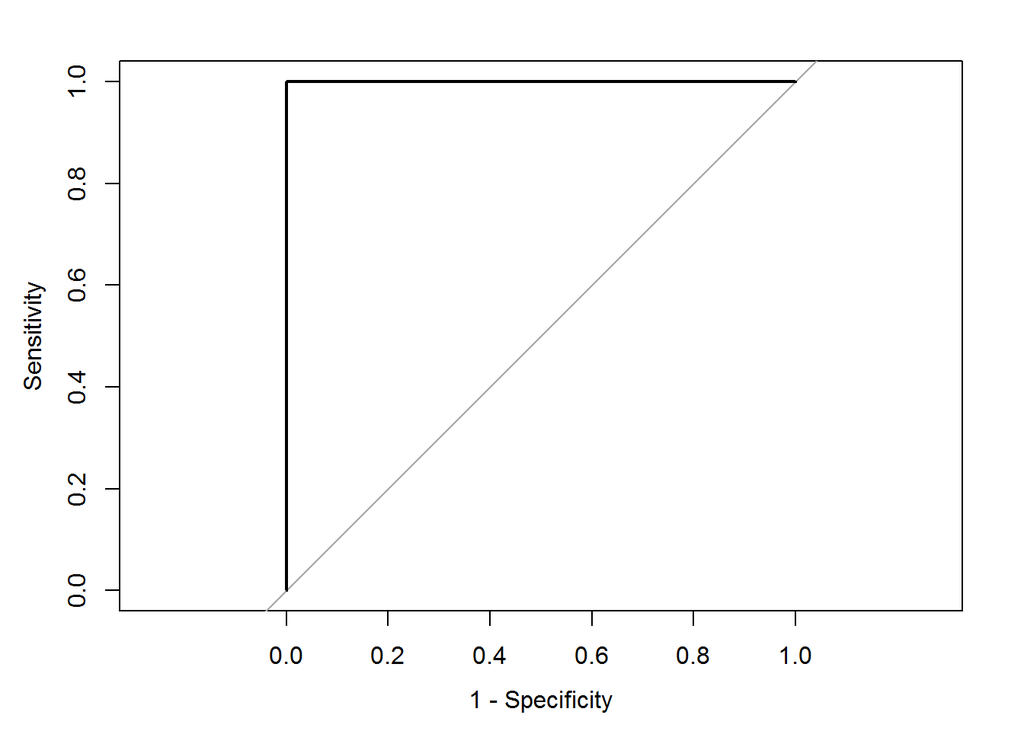

```
##
## Call:
## roc.default(response = BTUI.TST$CnMem.1.01.Standing, predictor = BTUI.TST$J48prob)
##
## Data: BTUI.TST$J48prob in 2412 controls (BTUI.TST$CnMem.1.01.Standing 0) < 1464 cases (BTUI.TST$CnMem.1.01.Standing 1).
## Area under the curve: 1
```

```r
plot(J48.BTUI.ROC, legacy.axes = TRUE)
```

```r
#j48 - weka verification
library(partykit)
#plot(J48.TRN.BTUI)
eval_J48.BTUI = evaluate_Weka_classifier(J48.TRN.BTUI, BTUI.TST, class=TRUE)
eval_J48.BTUI
```

```
##
## === Summary ===
##
## Correctly Classified Instances        3876              100      %
## Incorrectly Classified Instances         0                0      %
## Kappa statistic                          1
## Mean absolute error                      0
## Root mean squared error                  0
## Relative absolute error                  0      %
## Root relative squared error              0      %
## Coverage of cases (0.95 level)         100      %
## Mean rel. region size (0.95 level)      50      %
## Total Number of Instances             3876
##
## === Detailed Accuracy By Class ===
##
##                  TP Rate  FP Rate  Precision  Recall   F-Measure  MCC      ROC Area  PRC Area  Class
##                  1.000    0.000    1.000      1.000    1.000      1.000    1.000     1.000     0
##                  1.000    0.000    1.000      1.000    1.000      1.000    1.000     1.000     1
## Weighted Avg.    1.000    0.000    1.000      1.000    1.000      1.000    1.000     1.000
##
## === Confusion Matrix ===
##
##     a    b   <-- classified as
##  2412    0 |    a = 0
##     0 1464 |    b = 1
```